# passive multiple imputation in `mice`

Iris Eekhout

28 september 2018

This document demonstrates how to perform passive multiple imputation in a fictive simulated dataset that contains five multi-item questionnaires each containing 10 items. In this document the following packages are used: `mice`, `mitools` and `dmo`.

```r
library(mice)
library(mitools)
library(dmo)
```

## Generate simulated data

Data are generated for 100 subjects. Each subjects has observations for 5 questionnaires and 3 covariates.

```r
#generate questionnaire data
k <- c(10,10,10,10,10)
nq <- 5
x <- dmo::gen_qdata(n=100, k= k)

#generate covariate data
cov <- MASS::mvrnorm(n=100, mu=c(5,5,5), Sigma=matrix(c(10,1,1,1,10,1,1,1,10),3,3))
colnames(cov) <- c("cov1", "cov2", "cov3")

#combine in data.frame
x1 <- data.frame(x,cov)
```

### Generate missing values

Missing values are generated with the MAR mechanism for 25% of the subjects with a random pattern. Missings are only generated in the item scores (not in the covariates).

```r
alpha <- 0.25

#regerate 2 random patterns for missing item data
pattern <- matrix(c(sample(c(0,1), size=2*sum(k),replace = TRUE)),nrow=2)
pattern <- cbind(pattern, matrix(c(1,1,1,1,1,1),nrow=2))
pattern
```

```
##      [,1] [,2] [,3] [,4] [,5] [,6] [,7] [,8] [,9] [,10] [,11] [,12] [,13] [,14]
## [1,]    1    1    0    1    1    0    1    1    1     0     1     0     0     1
## [2,]    1    0    0    0    1    1    0    0    0     1     0     1     1     1
##      [,15] [,16] [,17] [,18] [,19] [,20] [,21] [,22] [,23] [,24] [,25] [,26]
## [1,]     0     0     1     0     0     0     1     1     0     1     0     0
## [2,]     1     1     1     0     1     1     0     1     1     1     1     1
##      [,27] [,28] [,29] [,30] [,31] [,32] [,33] [,34] [,35] [,36] [,37] [,38]
## [1,]     0     1     0     1     1     1     0     0     0     1     0     0
## [2,]     0     1     0     0     0     0     1     1     1     1     1     0
##      [,39] [,40] [,41] [,42] [,43] [,44] [,45] [,46] [,47] [,48] [,49] [,50]
## [1,]     0     0     0     1     1     1     0     0     1     0     0     1
## [2,]     1     0     0     0     1     0     1     1     1     1     0     1
##      [,51] [,52] [,53]
## [1,]     1     1     1
## [2,]     1     1     1
```

```r
#apply each pattern with equal frequency and equal odds
f <- c(0.5,0.5)
g <- c(4,4)

#generate missings in the data
x <- MAR(x1,alpha,pattern,f,g)
colnames(x) <- colnames(x1)

head(x, 15)
```

```
##          Q1_i1      Q1_i2      Q1_i3      Q1_i4      Q1_i5      Q1_i6
## 1   0.95577097  2.6992864 -1.8321872 -1.0418448  0.4794582  2.2536779
## 2   1.02189371 -2.5336485 -4.4202643 -1.1025024 -4.5405121 -3.0123306
## 3   3.56391723 -0.1635172         NA -1.5348315 -0.3973221         NA
## 4   0.60285781  0.3849449  1.2051629 -5.7030277  5.2109883  4.1140441
## 5   1.39773849  1.4265232         NA  1.1537959  3.5505728         NA
## 6   2.82750770  1.1223598  6.0774747 -0.9879557  0.7216776  2.6330646
## 7   0.30892578  3.3029560  2.1654957  4.8696553  2.1995167  3.1288252
## 8  -1.51920586  2.3813188  0.8228971  2.6136550  0.8454321  2.0850864
## 9  -2.08460063 -2.2789754 -2.1906825 -1.8227673  0.5770236  1.8278014
## 10  0.03651403         NA         NA         NA  0.9180559  3.4186183
## 11  1.84531939 -0.6672121  0.7541591 -0.5132101  2.2936016  2.9120290
## 12 -3.00914113 -1.6908507 -1.8225663 -1.2327063 -3.4533790 -5.9184506
## 13 -1.13044725  2.3414843  3.2944515 -1.2209058  1.9201881  3.1050647
## 14 -0.30559793  2.2566357  0.4476463  2.0604751 -3.1770323  0.2974634
```

[output cut: 129 more lines]

### Calculate total scores for questionnaires

Calculate the total scores (sum scores) for each questionnaire, only when all items are observed.

```r
ts <- dmo::calculate_ts(x, k= c(10,10,10,10,10))
data <- data.frame(x,ts)
```

## Passive multiple imputation

In passive multiple imputation, the item scores are imputed and then during the imputation, the total score is calculated based on the imputed item scores. These total scores can then be used as predictors for imputations of other variables.

There are 2 imputation models that are used in this procedure.

1. The total score of the questionnaires are imputed directly. This model only uses the total scores of the questionnaires an the three covariates. These imputed total scores are used for the subjects that have too many item scores missing, i.e. > 75%.
2. The item scores of the questionnaires are imputed, and the total scores are passively imputed, by re-calculating these after each imputation iteration. The re-calculated total scores are used as predictors to impute items from other questionnaires.

### Initialize imputation model for total score imputation

For this model, we can use the default settings used in `mice`.

```r
tsdata <- data.frame(ts, cov)
ini <- mice(tsdata, max=0, print=FALSE)
ini$meth
```

```
##  TSQ1  TSQ2  TSQ3  TSQ4  TSQ5  cov1  cov2  cov3
## "pmm" "pmm" "pmm" "pmm" "pmm"    ""    ""    ""
```

```r
ini$predictorMatrix
```

```
##      TSQ1 TSQ2 TSQ3 TSQ4 TSQ5 cov1 cov2 cov3
## TSQ1    0    1    1    1    1    1    1    1
## TSQ2    1    0    1    1    1    1    1    1
## TSQ3    1    1    0    1    1    1    1    1
## TSQ4    1    1    1    0    1    1    1    1
## TSQ5    1    1    1    1    0    1    1    1
## cov1    1    1    1    1    1    0    1    1
## cov2    1    1    1    1    1    1    0    1
## cov3    1    1    1    1    1    1    1    0
```

### Set up imputation model for passive imputation

For the passive imputation model, we need to adapt the methods for the total scores, and the predictor matrix for the items.

#### Methods

First the imputation method is adapted for the questionnaire total scores.

```r
ini <- mice(data, max=0, print=FALSE)
meth <- ini$meth

#for each questionnaire adapt imputation method (meth): make function to calculate TS between iterations. Example TS1:
#meth["TS1"] <- "~I(I1+I2+I3+I4+I5+I6+I7+I8+I9+I10)" - loop below automates for simulation data
nq <- 5
k <- c(10,10,10,10,10)
for(q in seq_along(1:nq)){
  meth[paste0("TSQ",q)] <- paste0("~I(", paste(paste0("Q", q, "_i",1:k[q]), collapse="+"), ")")
}
meth[c("TSQ1", "TSQ2", "TSQ3", "TSQ4", "TSQ5")]
```

```
##                                                               TSQ1
## "~I(Q1_i1+Q1_i2+Q1_i3+Q1_i4+Q1_i5+Q1_i6+Q1_i7+Q1_i8+Q1_i9+Q1_i10)"
##                                                               TSQ2
## "~I(Q2_i1+Q2_i2+Q2_i3+Q2_i4+Q2_i5+Q2_i6+Q2_i7+Q2_i8+Q2_i9+Q2_i10)"
##                                                               TSQ3
## "~I(Q3_i1+Q3_i2+Q3_i3+Q3_i4+Q3_i5+Q3_i6+Q3_i7+Q3_i8+Q3_i9+Q3_i10)"
##                                                               TSQ4
## "~I(Q4_i1+Q4_i2+Q4_i3+Q4_i4+Q4_i5+Q4_i6+Q4_i7+Q4_i8+Q4_i9+Q4_i10)"
##                                                               TSQ5
## "~I(Q5_i1+Q5_i2+Q5_i3+Q5_i4+Q5_i5+Q5_i6+Q5_i7+Q5_i8+Q5_i9+Q5_i10)"
```

#### Predictor matrix

The the predictor matrix is adapted such that items are imputed by items from their own questionnaire and other total scores. In predictor matrix: target variable is in row and the predictor variables are in the column. Below the predictor matrix for imputing the first 10 items is shown.

```r
pred <- ini$predictorMatrix
pred[paste0("Q1_i", 1:10),] <- 0
pred[paste0("Q1_i", 1:10),paste0("Q1_i", 1:10)] <- 1
pred[paste0("Q1_i", 1:10),c("TSQ2","TSQ3","TSQ4","TSQ5")] <- 1
pred[paste0("Q2_i", 1:10),] <- 0
pred[paste0("Q2_i", 1:10),paste0("Q2_i", 1:10)] <- 1
pred[paste0("Q2_i", 1:10),c("TSQ1","TSQ3","TSQ4","TSQ5")] <- 1
pred[paste0("Q3_i", 1:10),] <- 0
pred[paste0("Q3_i", 1:10),paste0("Q3_i", 1:10)] <- 1
pred[paste0("Q3_i", 1:10),c("TSQ2","TSQ1","TSQ4","TSQ5")] <- 1
pred[paste0("Q4_i", 1:10),] <- 0
pred[paste0("Q4_i", 1:10),paste0("Q4_i", 1:10)] <- 1
pred[paste0("Q4_i", 1:10),c("TSQ2","TSQ3","TSQ1","TSQ5")] <- 1
pred[paste0("Q5_i", 1:10),] <- 0
pred[paste0("Q5_i", 1:10),paste0("Q5_i", 1:10)] <- 1
pred[paste0("Q5_i", 1:10),c("TSQ2","TSQ3","TSQ4","TSQ1")] <- 1

pred[,colnames(cov)] <- 1 #covariates as predictors for all items
pred <- pred*ini$predictorMatrix
head(pred, 10)
```

```
##        Q1_i1 Q1_i2 Q1_i3 Q1_i4 Q1_i5 Q1_i6 Q1_i7 Q1_i8 Q1_i9 Q1_i10 Q2_i1 Q2_i2
## Q1_i1      0     1     1     1     1     1     1     1     1      1     0     0
## Q1_i2      1     0     1     1     1     1     1     1     1      1     0     0
## Q1_i3      1     1     0     1     1     1     1     1     1      1     0     0
## Q1_i4      1     1     1     0     1     1     1     1     1      1     0     0
## Q1_i5      1     1     1     1     0     1     1     1     1      1     0     0
## Q1_i6      1     1     1     1     1     0     1     1     1      1     0     0
## Q1_i7      1     1     1     1     1     1     0     1     1      1     0     0
## Q1_i8      1     1     1     1     1     1     1     0     1      1     0     0
## Q1_i9      1     1     1     1     1     1     1     1     0      1     0     0
## Q1_i10     1     1     1     1     1     1     1     1     1      0     0     0
##        Q2_i3 Q2_i4 Q2_i5 Q2_i6 Q2_i7 Q2_i8 Q2_i9 Q2_i10 Q3_i1 Q3_i2 Q3_i3 Q3_i4
## Q1_i1      0     0     0     0     0     0     0      0     0     0     0     0
## Q1_i2      0     0     0     0     0     0     0      0     0     0     0     0
## Q1_i3      0     0     0     0     0     0     0      0     0     0     0     0
## Q1_i4      0     0     0     0     0     0     0      0     0     0     0     0
## Q1_i5      0     0     0     0     0     0     0      0     0     0     0     0
## Q1_i6      0     0     0     0     0     0     0      0     0     0     0     0
## Q1_i7      0     0     0     0     0     0     0      0     0     0     0     0
## Q1_i8      0     0     0     0     0     0     0      0     0     0     0     0
## Q1_i9      0     0     0     0     0     0     0      0     0     0     0     0
## Q1_i10     0     0     0     0     0     0     0      0     0     0     0     0
##        Q3_i5 Q3_i6 Q3_i7 Q3_i8 Q3_i9 Q3_i10 Q4_i1 Q4_i2 Q4_i3 Q4_i4 Q4_i5 Q4_i6
## Q1_i1      0     0     0     0     0      0     0     0     0     0     0     0
## Q1_i2      0     0     0     0     0      0     0     0     0     0     0     0
## Q1_i3      0     0     0     0     0      0     0     0     0     0     0     0
## Q1_i4      0     0     0     0     0      0     0     0     0     0     0     0
## Q1_i5      0     0     0     0     0      0     0     0     0     0     0     0
## Q1_i6      0     0     0     0     0      0     0     0     0     0     0     0
## Q1_i7      0     0     0     0     0      0     0     0     0     0     0     0
## Q1_i8      0     0     0     0     0      0     0     0     0     0     0     0
## Q1_i9      0     0     0     0     0      0     0     0     0     0     0     0
## Q1_i10     0     0     0     0     0      0     0     0     0     0     0     0
##        Q4_i7 Q4_i8 Q4_i9 Q4_i10 Q5_i1 Q5_i2 Q5_i3 Q5_i4 Q5_i5 Q5_i6 Q5_i7 Q5_i8
## Q1_i1      0     0     0      0     0     0     0     0     0     0     0     0
## Q1_i2      0     0     0      0     0     0     0     0     0     0     0     0
## Q1_i3      0     0     0      0     0     0     0     0     0     0     0     0
## Q1_i4      0     0     0      0     0     0     0     0     0     0     0     0
## Q1_i5      0     0     0      0     0     0     0     0     0     0     0     0
## Q1_i6      0     0     0      0     0     0     0     0     0     0     0     0
## Q1_i7      0     0     0      0     0     0     0     0     0     0     0     0
## Q1_i8      0     0     0      0     0     0     0     0     0     0     0     0
## Q1_i9      0     0     0      0     0     0     0     0     0     0     0     0
## Q1_i10     0     0     0      0     0     0     0     0     0     0     0     0
##        Q5_i9 Q5_i10 cov1 cov2 cov3 TSQ1 TSQ2 TSQ3 TSQ4 TSQ5
## Q1_i1      0      0    1    1    1    0    1    1    1    1
## Q1_i2      0      0    1    1    1    0    1    1    1    1
## Q1_i3      0      0    1    1    1    0    1    1    1    1
## Q1_i4      0      0    1    1    1    0    1    1    1    1
## Q1_i5      0      0    1    1    1    0    1    1    1    1
## Q1_i6      0      0    1    1    1    0    1    1    1    1
## Q1_i7      0      0    1    1    1    0    1    1    1    1
## Q1_i8      0      0    1    1    1    0    1    1    1    1
## Q1_i9      0      0    1    1    1    0    1    1    1    1
## Q1_i10     0      0    1    1    1    0    1    1    1    1
```

## Apply final imputations

For both imputation procedures we use 15 imputations and 10 iterations. The object `imp1` contains the imputations for the total scores only from other total scores and the thee covariates. The object `imp2` for items and total scores with passive imputation.

```r
imp1 <- mice(tsdata, 15,maxit=10,seed=61085,print=FALSE)
imp2 <- mice(data, m=15, meth=meth,pred=pred, maxit=10, seed=12354, print=FALSE)
```

### Check iteration plots

The the imputations for the Total scores in the total score imputation (`imp1`) passive imputation procedure (`imp2`).

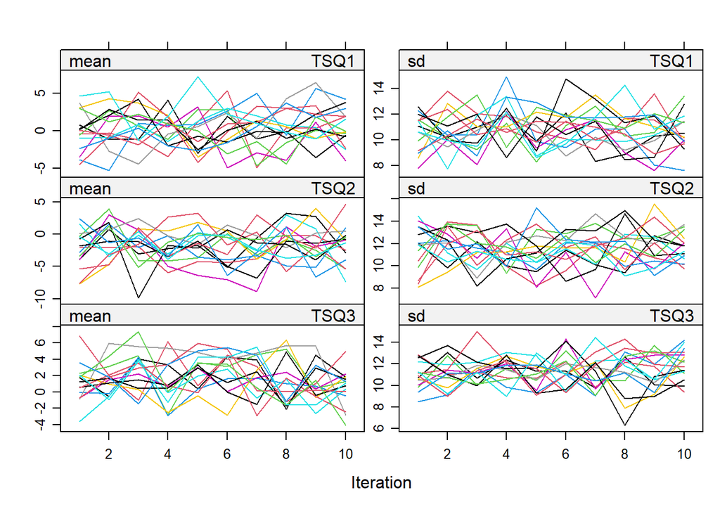

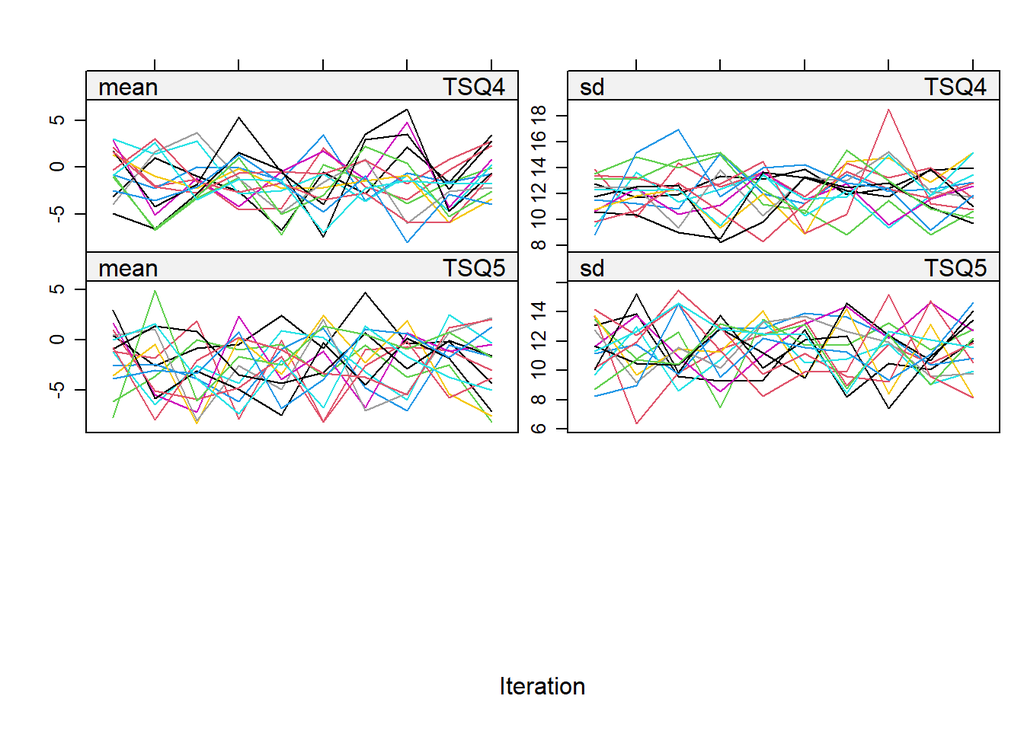

```r
plot(imp1, paste0("TSQ",1:5))
```

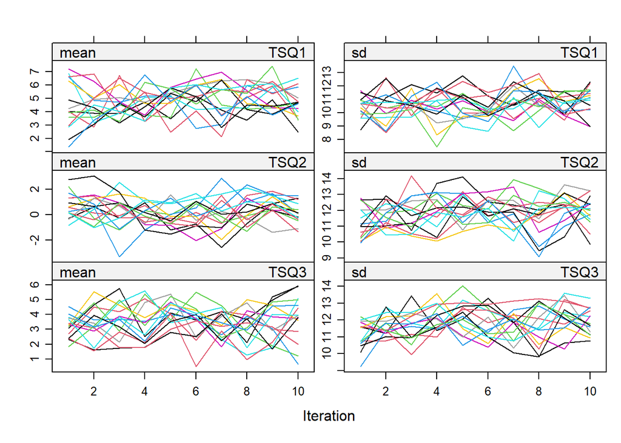

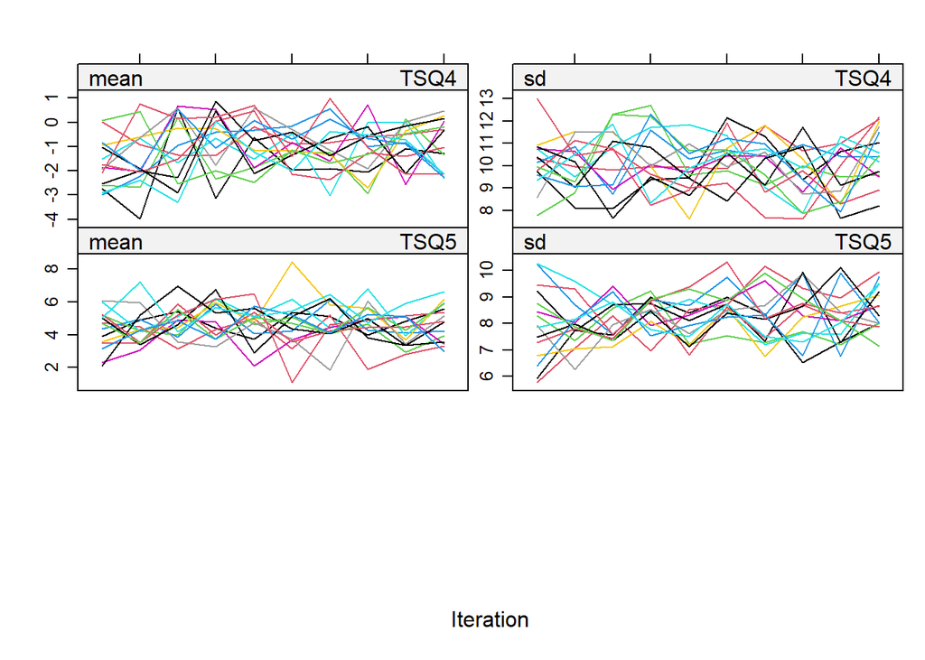

```r
plot(imp2, paste0("TSQ",1:5))
```

## Combine imputations

First make indicators for each q if missing <75%:

```r
calculate_i <- function(x,nq,k){
  ind <- matrix(0,nrow=nrow(x), ncol=(nq))

  for (q in 1:(nq)){
    ind[,q] <- apply(x[,(((q*k[q])-k[q])+1):(q*k[q])],1,function(x) {sum(is.na(x))/length(x)})
  }
  colnames(ind) <- paste("TS",1:nq,sep="")
  ind <- ifelse(ind <0.75,1,0)
  ind
}
indicator <- calculate_i(x=data, nq=5, k=c(10,10,10,10,10))
```

Then select correct TS from each imputation.

```r
implist <- lapply(1:15, function(x){
  x1 <- complete(imp1, x)
  x2 <- complete(imp2, x)
  tsimp <- lapply(1:nq, function(x){
    ifelse(indicator[,x]==1, x2[,paste0("TSQ",x)], x1[,paste0("TSQ",x)] )
  })
  tsimp <- data.frame(tsimp)
  colnames(tsimp) <- paste0("impTSQ",1:nq)
  data.frame(x1,tsimp)
})
```

## Analyze and pool

Save data in an imputation list for analysis and test relation between TS1 and TS3

```r
impdata <- imputationList(implist)
fit <- with (impdata, lm(impTSQ1~impTSQ3 ))
summary(pool (fit))
```

```
##          term   estimate std.error statistic       df   p.value
## 1 (Intercept) 0.78735793 1.1613389 0.6779743 89.31883 0.4995406
## 2     impTSQ3 0.05329066 0.1043346 0.5107669 75.46031 0.6110054
```